# Python in R with reticulate

Allison Horst

## 2. Python in R Markdown with `reticulate()`

### Some background:

[`reticulate`](https://rstudio.github.io/reticulate/): “R interface to Python modules, classes, and functions. When calling into Python R data types are automatically converted to their equivalent Python types. When values are returned from Python to R they are converted back to R types. The reticulate package is compatible with all versions of Python >= 2.7. Integration with NumPy requires NumPy version 1.6 or higher.”

- **Note 1:** you need to have Python >=2.7 installed on your computer (what I did: Anaconda download). The `reticulate` package **does not** bring Python along with it. Then you can follow along [here](https://rstudio.github.io/reticulate/) to get up and running with functioning Python code chunks in R Markdown.

#### a. Tell R which Python version to use (if needed)

```r
# use_python("path/to/python")
# py_config()
```

#### b. Install Python libraries

```r
# py_install("scipy")
```

There are a number of ways to do this, some easier than this. Check out: https://rstudio.github.io/reticulate/index.html for a lot of examples and information.

#### c. Just generally working in a Py code chunk

…nothing super special here.

```python
a = 4
b = 10
c = a + b
c
```

```
## 14
```

Looks very similar to what we’d do in R:

```r
a = 4
b = 10
c = a + b
c
```

```
## [1] 14
```

#### d. I already have `pandas`, `matplotlib.pyplot` and `dplython` installed, so I can import them here:

- `pandas` is used for exploring & wrangling data frames (also using tidy structure)
- `matplotlib` is a basic graphics module
- `dplython` has functions for wrangling that are similar to `dplyr` in R

Here, I give it a shorter name (“pd”) to make it quicker to refer to when I use it later on, but don’t have to.

```python
# Attach modules
import pandas as pd
import matplotlib.pyplot as mp
# Get specific pieces from dplython
from dplython import (DplyFrame, X, head, arrange, mutate, select, group_by, summarize)
```

#### e. Reading in and exploring data

Comparison of common functions: https://pandas.pydata.org/docs/getting_started/comparison/comparison_with_r.html

**Example 1:** Starting from `my_data.csv`

- Do some exploring first with R code (View, head, tail, names, dim)

```r
df_r <- read_csv(here("data", "my_data.csv"))

View(df_r) # Return entire data frame
head(df_r) # Return first 6 lines
```

```
## # A tibble: 6 x 4
##   id        species weight_lb height_m
##   <chr>     <chr>       <dbl>    <dbl>
## 1 Fluffster cat          12.1     0.28
## 2 Tailster  dog          34.8     0.64
## 3 Lilpaws   mouse         0.2     0.03
## 4 Catfriend cat           9.3     0.35
## 5 Doggo     dog          51.6     0.51
## 6 Longface  horse      1842.      2.18
```

```r
tail(df_r) # Return last 6 lines
```

```
## # A tibble: 6 x 4
##   id        species weight_lb height_m
##   <chr>     <chr>       <dbl>    <dbl>
## 1 Fluffster cat          12.1     0.28
## 2 Tailster  dog          34.8     0.64
## 3 Lilpaws   mouse         0.2     0.03
## 4 Catfriend cat           9.3     0.35
## 5 Doggo     dog          51.6     0.51
## 6 Longface  horse      1842.      2.18
```

```r
names(df_r) # Return variable names
```

```
## [1] "id"        "species"   "weight_lb" "height_m"
```

```r
dim(df_r) # Return dimensions
```

```
## [1] 6 4
```

Let’s do the same with Python code!

First: read it in (`pandas.read_csv`)

```python
df_py = DplyFrame(pd.read_csv("../data/my_data.csv"))
```

Then look at it using similar functions:

```python
print(df_py) # View it
```

```
##           id species  weight_lb  height_m
## 0  Fluffster     cat       12.1      0.28
## 1   Tailster     dog       34.8      0.64
## 2    Lilpaws   mouse        0.2      0.03
## 3  Catfriend     cat        9.3      0.35
## 4      Doggo     dog       51.6      0.51
## 5   Longface   horse     1842.3      2.18
```

```python
df_py.head(3) # Return the first 3 rows
```

```
##           id species  weight_lb  height_m
## 0  Fluffster     cat       12.1      0.28
## 1   Tailster     dog       34.8      0.64
## 2    Lilpaws   mouse        0.2      0.03
```

```python
df_py.tail(2) # Return the last 2 rows
```

```
##          id species  weight_lb  height_m
## 4     Doggo     dog       51.6      0.51
## 5  Longface   horse     1842.3      2.18
```

```python
list(df_py) # Return the column names
```

```
## ['id', 'species', 'weight_lb', 'height_m']
```

```python
df_py.shape # Returns dimensions
```

```
## (6, 4)
```

### Now let’s do some wrangling and see the similarities between R and Python for some staples

- Only keep observations where weight is greater than 12 pounds
- Just keep columns species, weight_lb and height_m
- Add a new column for the weight/height ratio
- Make a graph with ggplot2

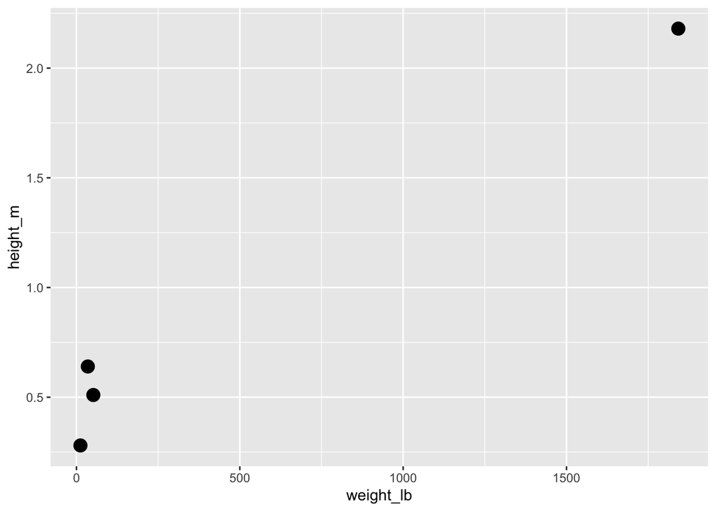

```r
# Do the wrangling:
foo_r <- df_r %>%
  filter(weight_lb > 12) %>%
  select(species, weight_lb, height_m) %>%
  mutate(ratio = weight_lb / height_m)

# Then make a graph with ggplot2:
ggplot(data = foo_r, aes(x = weight_lb, y = height_m)) +
  geom_point(size = 4)
```

Let’s do the same in Python Note: `>>` operator is in `dplython` module

```python
foo_py = df_py >> select(X.weight_lb, X.height_m) >> X.query('weight_lb > 12') >> X.assign(ratio = X['weight_lb'] / X['height_m'])

print(foo_py)

# So it's the same thing, and we can plot with matplotlib
```

```
##    weight_lb  height_m       ratio
## 0       12.1      0.28   43.214286
## 1       34.8      0.64   54.375000
## 4       51.6      0.51  101.176471
## 5     1842.3      2.18  845.091743
```

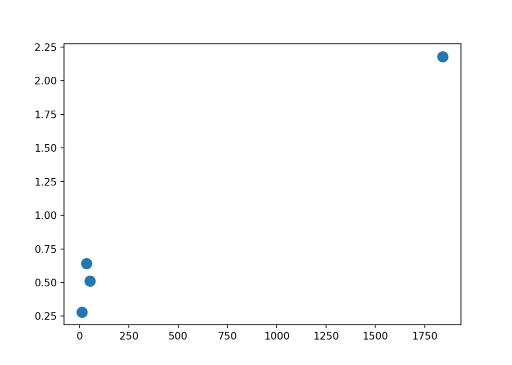

```python
mp.scatter('weight_lb', 'height_m', s = 100, data = foo_py)
```

But also, what if I just want to get this to be an R data frame? No problem!

```r
my_df <- py$df_py
class(my_df)
```

```
## [1] "data.frame"
```

We have seen a number of different ways to use Python in RStudio, and with R code, including:

1. Run Python scripts (.py) in R Studio
2. Write Python code in R Markdown thanks to `reticulate`
3. Call Python objects (e.g. pandas DataFrames) in R code chunks with `py$object_name`